# Module 5

[figure not shown]

# Module 5: What is Git and why is it useful?

Git is a software document version control system (https://git-scm.com/book/en/v1/Getting-Started-Git-Basics). Typically, many people track versions of files by adding numbers (e.g. docv1, docv2, docv3) or dates (doc02012018, doc02052018, doc02142018). Many versions of a project document can lead to a file management headache (not to mention a project directory mess) that is associated with the proliferation of dozens of file versions over the course of a project. Git tracks file versions behind the scenes so that you only see your current file version in your directory. Git has been most commonly used in the field of computer science to allow version control of computer code and to allow for collaborative coding between people working on the same project. It has more recently become recognized as an essential tool for helping to ensure reproducible research.

## How does Git work in a nutshell?

Git works by taking what you can think of as ‘snapshots’ at a point in time of a file that the user has put under version control. In the image below, there are three files that are being tracked by Git (A, B, and C). In version 2 (i.e. at snapshot time 2), files A and C have changes but B has not. In version 3 (i.e. at snapshot time 3), only file C has changed.

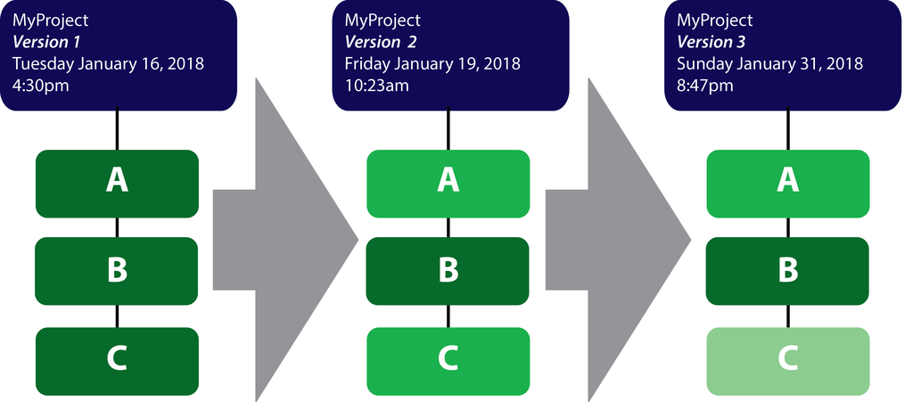

## What is GitHub and why is it useful?

GitHub is a ‘remote’ website and file repository that allows you to store files and their versions on an accessbile cloud-based server platform. You can use GitHub as a central location to store your file versions and work collaboratively by `push`ing file versions from your computer using Git software to a GitHub repository. Your collaborator can `pull` the most current file version from a shared repository, add their changes, and then `push` it back for you to `pull` and work on. It can serve as a repository for any file type (coding, word processing, images, etc.). Think of it like a Facebook for nerds (we are nerds so we mean that in the most flattering way possible), allowing them to efficiently collaborate on code and other types of electronic documents, including sharing the products of their work with the world and commenting on and making changes to the products of others.

## Working with Git and GitHub

There are many different software programs for version control. We will give instructions for two commonly used programs in this module: *Git Bash* and *GitHub Desktop*. Git Bash is a popular command line interface (CLI) that uses Unix commands and GitHub desktop is a point-and-click graphical user interface (GUI) application. Both are free and allow you to do local version control as well as transferring versions of files back and forth from your local computer to GitHub for remote version control and collaboration.

## Step-by-step instructions for using Git Bash in conjunction with GitHub

### 1. Create a GitHub account.

Go to: https://github.com to create an account. For more detailed instructions on using GitHub than are provided below, please see: https://guides.github.com/activities/hello-world/.

### 2. Download and install Git Bash.

**For Mac users**, you can download and install Git Bash from: https://git-scm.com/download/mac. *Helpful tip:* If you get an error message that your security preferences do not allow Git to be opened, go into system preferences -> security & privacy -> general and you can select “open anyways”. If you can’t find Git after you download it: Go to finder -> Go (drop down menu) -> Go to the folder: (then type folder path and it will probably be “usr/local/bin”). You can drag the folder labeled “git” to another, easier to find location of your choice. If you are not sure of the folder path, go into Git installer, then open the readme.txt and it should tell you the path.

**For Windows users**, you can download and install Git Bash from: https://git-scm.com/download/win

### 3. Set up Git Bash with user name and your email that you used for your GitHub account.

To set up your user name: `$ git config --global user.name "Your user name"`

To set up your user email: `$ git config --global user.email [enter your email address here without brackets]`

[figure not shown]

### 4. Create a directory for version control and change your directory in Git Bash to this directory.

The first thing you need to do to put a file or files under version control is create a project directory (a folder) on your computer if you don’t have one already in mind. Open Git Bash and change the directory to the one that you will put under version control using the `cd` command followed by the path in quotation marks as shown below.

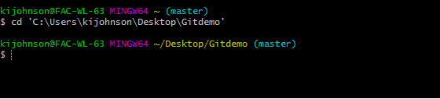

*Note: On Mac, you will be doing all of this in the terminal. You can find the terminal by searching “Terminal” in the search bar.*

For more help with setting up git: https://docs.gitlab.com/ce/gitlab-basics/start-using-git.html

`$ git init`

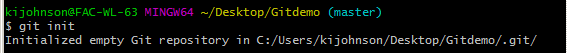

### 6. `Add` a file for version control tracking.

If you do not have an existing file you want to add for the purposes of this tutorial, you can make an empty text file using notepad or some other text editor. I made a file containing the text ‘hello world’ and saved it as helloworld.txt in my master directory. Once I have the file, I can now add it for tracking by git using the `git add` command.

The helloworld.txt file has now been added to what is commonly referred to as the ‘staging’ environment and is ready to be `commit`ted as a snapshot (i.e. a version).

### 7. Use the `git commit` command to record changes in your file to your local repository.

You can include a message with `git commit` to provide information about the changes made to the file or if it is your first file you can include any message you want associated with the file. This is helpful so that you or your collaborators know what changes occured in each version. This is all you have to do if you just want to control versions of your files locally. If you want to add the version controlled files to a remote repository (such as one on GitHub), read on!

`$ git commit -m 'This is my first commit!'`

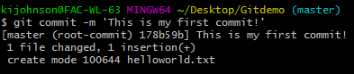

### 8. Create a project repository on GitHub.

Go to your GitHub site. To create a new repository: Click the “+” sign next to your icon (in the upper right hand corner of the screen) and select “New repository” and provide it a name that is associated with the project. You can also click on the green ‘New repository button’ on the right hand side of the screen. I am going to call my Github repository *Git_demo_files*. Click on “Initialize this repository with a README’ and then click the green ‘Create repository’ button.

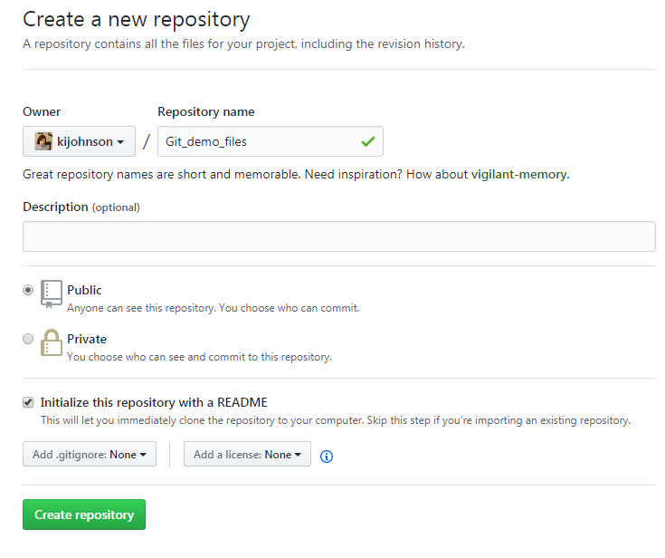

### 9. Link your local repository to the new Github repository you created on GitHub using the `git remote add origin` command.

The origin (the location address of your remote repository) will now tag the GitHub location for the files to be stored. The origin can be found by clicking on the green Clone or download button and copying the link shown in the ‘Clone with HTTPS’ box.

`$ git remote add origin https://github.com/kijohnson/Git_demo_files.git`

[figure not shown]

### 10. Use the `git push` command to upload `commit`ted files in your local repository (master) to GitHub.

`$ git push -u -f origin master`

[figure not shown]

You should see the helloworld.txt file now in your GitHub repository.

*Note: You might be prompted for your username and password, just type each and press enter* *Your password may not appear, but just trust that you typed it correctly, if you typed it incorrectly then just restart this step* *Note: For second pushes to the repository omit the ‘-f’. The f stands for force (To read more: https://git-scm.com/docs/git-push). This is needed only the first time you push to a GitHub repository that has been initialized with a readme file because you local repository does not contain the readme file. To prevent this from happening, you may want to create an empty GitHub repository containing only a readme file and clone it as below to start local version control and pushing files to GitHub.

## Clone a repository from GitHub to your local machine with Git Bash.

You can also clone a GitHub repository to your local machine to start version control instead of creating a directory as in step 4. To clone a GitHub repository that you or your collaborator creates on GitHub, go to the GitHub repository and click the green **Clone or download** button and then **Download to zip**.

[figure not shown]

In the zipped folder, there will be a copy of the repository that you can transfer to a location on your computer.

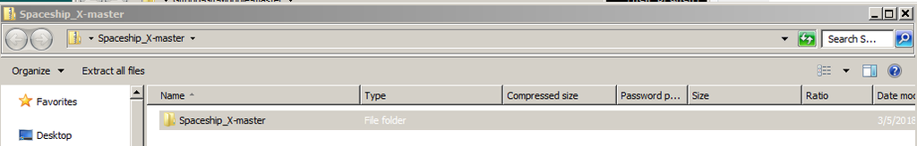

Then follow steps 4-7 (for step 4 start with `cd`) and 10 to push versions of files to the GitHub repository.You can also `pull` versions from the GitHub repository that your collaborator has updated so that you have the most recent version using `git pull origin master` and repeat the cycle (work on the new file version, `add` it as a new version, `commit` it as a new version, and then `push` it back to the GitHub repository).

## Final words on Git Bash.

It gets more complicated than this but this should be enough to get you started with organized file management through git version control. To learn about branching and merging, which are pretty important concepts when working collaboratively, see this excellent resource: https://git-scm.com/book/en/v2

### Other useful commands (from various sources):

To change GitHub repositories:

`$ git remote rm origin`

To remove all files from the staging area:

`$ git reset HEAD -- .`

To remove single file from staging area:

`$ git reset HEAD -- path/to/file`

To see files that are to be committed (those in your staging area):

`$ git diff --cached`

To see files in staging area:

`$ git status`

To revert to an earlier version of a file:

`$ git reset - -hard 'commit hash`

To reset a file version to an earlier commit. Note for ‘commit hash’, you need to insert the long or abbreviated alphanumeric number for the commit that can be determined by getting a graph of commits with abbreviated hash numbers for each commit (for output options, see: https://gitscm.com/book/en/v2/Git-Basics-Viewing-the-Commit-History):

`$ git log --pretty=format:"%h %s"--graph`

## Step-by-step instructions for GitHub desktop

### 1. Create a GitHub account

Go to: https://github.com to create an account. For more detailed instructions on using GitHub than are provided below, see: https://guides.github.com/activities/hello-world/.

### 2. Download and install GitHub desktop

For 64-bit Windows: https://central.github.com/deployments/desktop/desktop/latest/win32

For Mac OS: https://central.github.com/deployments/desktop/desktop/latest/darwin

Or go to https://desktop.github.com/ and find the version for your machine.

### 3. Open GitHub desktop, sign in and initialize a repository

When you first open GitHub desktop, you will be prompted to enter your user name and password from github.com. Enter these, and click File –> New repository.

Enter a name for your new repository. I called mine *Project1*, and in the description box, I typed *This is my first GitHub repo*. I then changed the local path from the default to a more convenient directory (I used the desktop). Finally, I clicked the box for “Initialize this repository with a readme” and then “Create repository”. The readme file is optional and it is a text file created with the repository name in it and nothing else. If you choose to create it here, you can open it on your machine and put more information about the repository in it for you and your team (*e.g.*, a list of all the files you’ve added with more details about each, a brief project overview).

[figure not shown]

### 4. Save project file(s) in the repository folder

If you already have a project you’re working on and would like to store/share on GitHub, copy and paste, drag and drop, or otherwise move those files to the new project folder/repository you’ve created. For this guide, I created a text file with “hello world” in it, because I have no imagination, and saved it as helloWorld.txt in the *Project1* folder. Feel free to do so if you don’t have other files handy or ready for prime time.

### 5. Commit changes to the repository

Once you’ve moved your files to your version of the *Project1* folder, they should appear in GitHub desktop unter the “Changes” tab. In the lower left corner there are two boxes, one for a summary and one for a description. Type something in the summary box (I used “This is a test”) and if you like, type a longer description in the description box (I used “My first GitHub commit!”). The summary box is required, and the description box is optional. You can always add more to these or change them later.

[figure not shown]

Click “Commit to master”. The large GitHub desktop panel will change to read “No local changes…”

[figure not shown]

### 6. Send your new repository to your GitHub account

When you’re ready to send your new repo to GitHub, click on “Publish repository” toward the top right of GitHub desktop. A popup will show you the details of the repository. Unless you have an upgraded (paid) GitHub account, you need to de-click the “Keep this code private” box. Review the other information and then click “Publish repository”.

Switch to your browser and go to github.com to verify that your repository is there. Each time you’re working on your project, open GitHub desktop and 1) commit changes, then 2) “Push” the repo to your online GitHub account to save changes in the cloud. You can use the Repository menu –> Push, or use the keyboard shortcut *Ctrl P* to push changes once committed.

### Cloning a repository from Github to your local machine with Git Desktop

If another team member created a repository that you’re using, or if you find a repository you’d like to have, you can save a local copy to work on yourself and then commit changes and push them to GitHub online.

- From GitHub desktop, simply click on File –> Clone Repository
- Choose one of your existing repositories or fill in the URL to the repository you’d like to save locally
- Ensure that the local path points where you would like and click “Clone”
- Now you can edit the repo like normal and commit, push, and share changes.

## Git and GitHub dictionary of commonly used terms

- **Branch**. The default branch is called the master branch and proceeds as a linear set of “snapshots” of a directory of files under version control. Users can also *branch* off the master branch to make changes to a version without having it effect the versions being tracked on the master branch. A user may want to do this to make some changes to code for example that they want to test but aren’t sure yet if they will work and be incorporated into the working version of the code.
- **Clone**. Allows you to clone a remote existing repository from Github to your local computer giving you access to all files in that repository. When you clone a repository a *.git* subdirectory is automatically initialized.
- **Commit**. Allows you to stage the file for pushing to the remote repository
- **Diff**. Allows you to check what has been added but not yet staged (committed)
- **Fork**. Allows you to copy another repository and start working on it indepdendently. You can also pull updates from the parent repository to your forked repository
- **Local**. The version controlled respoistory on your local machine
- **Master**. The default branch for git commits
- **Merge**. This git command is used to merge changes from different versions (e.g. merge changes in a branch to the most recent version on the master branch)
- **Origin**. An alias for a remote reposiotry URL
- **Pull**. Pull files from a remote repository (e.g. Github) to your local repository
- **Push**. Push files from a local repository to a remote repository (e.g. Github)
- **Remote**. The respository at a remote site.
- **Status**. Allows you to check the status of tracked and untracked files

## Other Resources

- https://www.kernel.org/pub/software/scm/git/docs/gittutorial.html
- https://docs.gitlab.com/ce/gitlab-basics/start-using-git.html
- Using Git/SVN from RStudio: https://www.r-bloggers.com/rstudio-and-github/
- https://git-scm.com/book/en/v2/Git-Branching-Branches-in-a-Nutshell